# Supervised learning: Classification 1

# Introduction

In this practical, we will learn about three different classification methods: K-nearest neighbours, logistic regression, and linear discriminant analysis.

One of the packages we are going to use is `class`. For this, you will probably need to `install.packages("class")` before running the `library()` functions.

```r
library(MASS)
library(class)
library(ISLR)
library(tidyverse)
```

# Default dataset

The default dataset contains credit card loan data for 10 000 people. The goal is to classify credit card cases as `yes` or `no` based on whether they will default on their loan.

1. **Create a scatterplot of the `Default` dataset, where `balance` is mapped to the x position, `income` is mapped to the y position, and `default` is mapped to the colour. Can you see any interesting patterns already?**

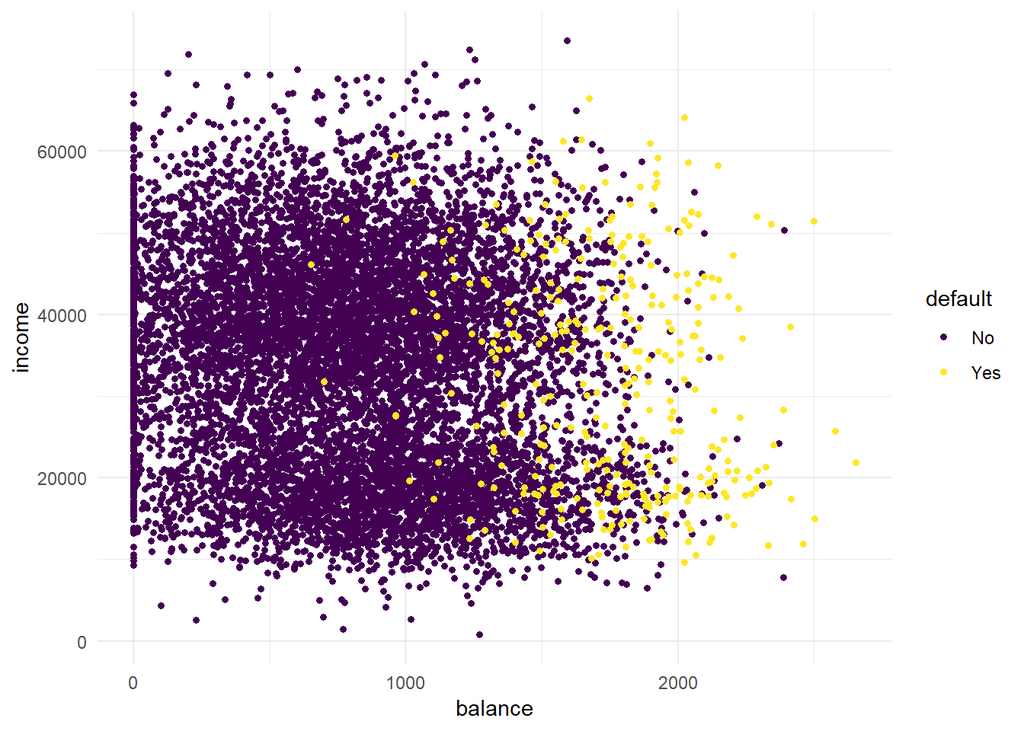

```r
Default %>%
  arrange(default) %>% # so the yellow dots are plotted after the blue ones
  ggplot(aes(x = balance, y = income, colour = default)) +
  geom_point(size = 1.3) +
  theme_minimal() +
  scale_colour_viridis_d() # optional custom colour scale
```

```r
# People with high remaining balance are more likely to default.
# There seems to be a low-income group and a high-income group
```

2. **Add `facet_grid(cols = vars(student))` to the plot. What do you see?**

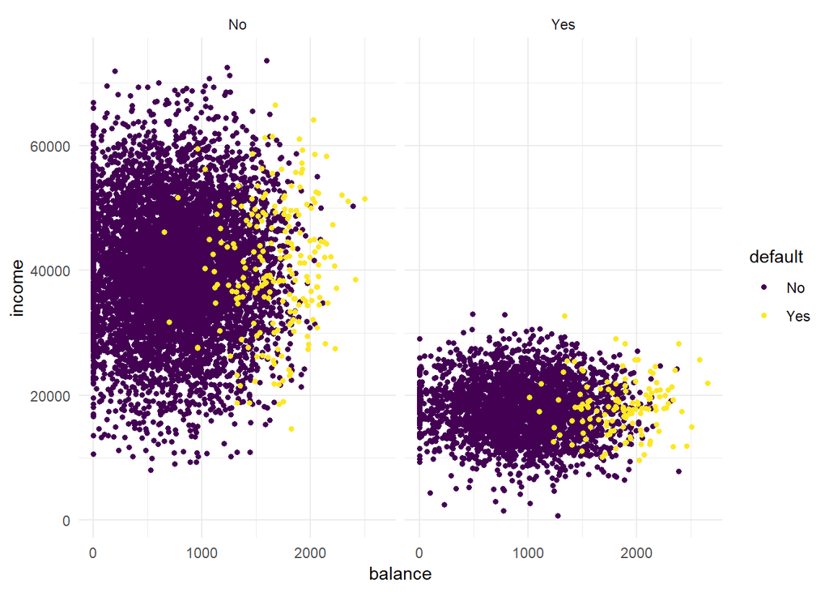

```r
Default %>%
  arrange(default) %>% # so the yellow dots are plotted after the blue ones
  ggplot(aes(x = balance, y = income, colour = default)) +
  geom_point(size = 1.3) +
  theme_minimal() +
  scale_colour_viridis_d() +
  facet_grid(cols = vars(student))
```

```r
# The low-income group is students!
```

3. **Transform “student” into a dummy variable using `ifelse()` (0 = not a student, 1 = student). Then, randomly split the Default dataset into a training set `default_train` (80%) and a test set `default_test` (20%)**

```r
default_df <-
  Default %>%
  mutate(student = ifelse(student == "Yes", 1, 0)) %>%
  mutate(split = sample(rep(c("train", "test"), times = c(8000, 2000))))

default_train <-
  default_df %>%
  filter(split == "train") %>%
  select(-split)

default_test <-
  default_df %>%
  filter(split == "test") %>%
  select(-split)
```

# K-Nearest Neighbours

Now that we have explored the dataset, we can start on the task of classification. We can imagine a credit card company wanting to predict whether a customer will default on the loan so they can take steps to prevent this from happening.

The first method we will be using is k-nearest neighbours (KNN). It classifies datapoints based on a majority vote of the k points closest to it. In `R`, the `class` package contains a `knn()` function to perform knn.

4. **Create class predictions for the test set using the `knn()` function. Use `student`, `balance`, and `income` (but no basis functions of those variables) in the `default_train` dataset. Set k to 5. Store the predictions in a variable called `knn_5_pred`.**

```r
knn_5_pred <- knn(
  train = default_train %>% select(-default),
  test  = default_test  %>% select(-default),
  cl    = as_factor(default_train$default),
  k     = 5
)
```

5. **Create two scatter plots with income and balance as in the first plot you made. One with the true class (`default`) mapped to the colour aesthetic, and one with the predicted class (`knn_5_pred`) mapped to the colour aesthetic. Hint: Add the predicted class `knn_5_pred` to the `default_test` dataset before starting your `ggplot()` call of the second plot. What do you see?**

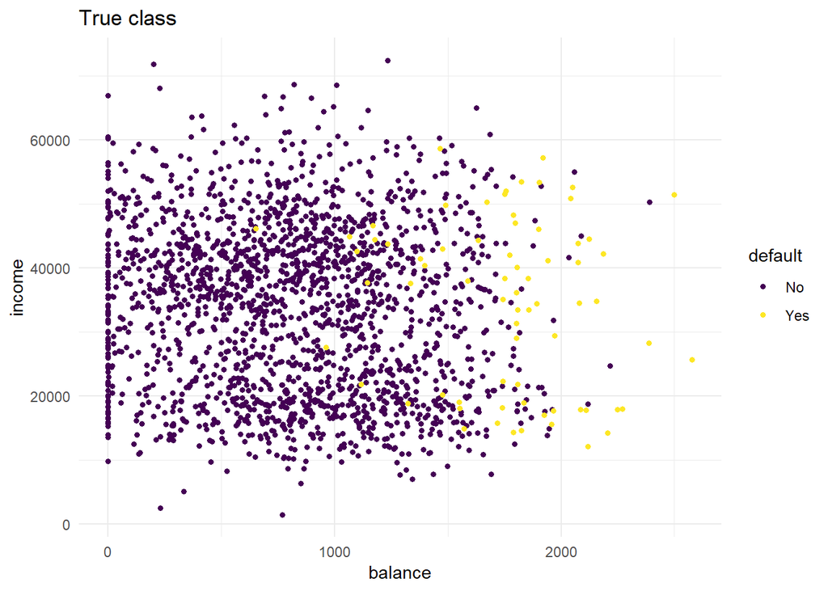

```r
# first plot is the same as before
default_test %>%
  arrange(default) %>%
  ggplot(aes(x = balance, y = income, colour = default)) +
  geom_point(size = 1.3) +
  scale_colour_viridis_d() +
  theme_minimal() +
  labs(title = "True class")
```

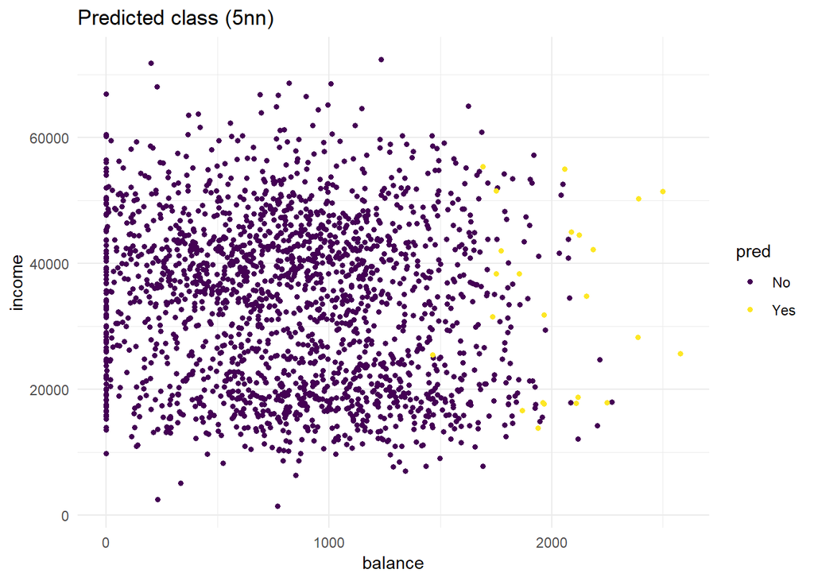

```r
# second plot maps pred to colour
bind_cols(default_test, pred = knn_5_pred) %>%
  arrange(default) %>%
  ggplot(aes(x = balance, y = income, colour = pred)) +
  geom_point(size = 1.3) +
  scale_colour_viridis_d() +
  theme_minimal() +
  labs(title = "Predicted class (5nn)")
```

```r
# there are quite some misclassifications: many "No" predictions
# with "Yes" true class and vice versa.
```

6. **Repeat the same steps, but now with a `knn_2_pred` vector generated from a 2-nearest neighbours algorithm. Are there any differences?**

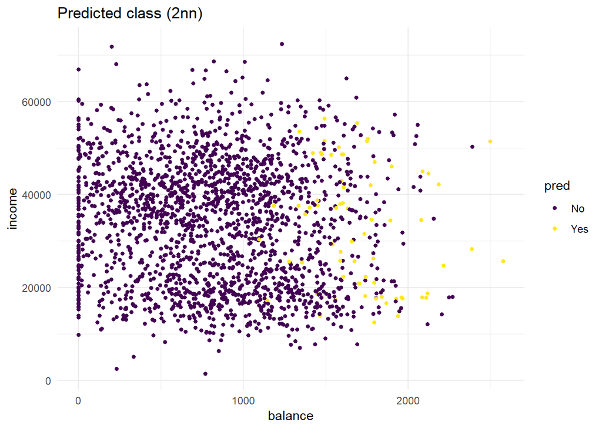

```r
knn_2_pred <- knn(
  train = default_train %>% select(-default),
  test  = default_test  %>% select(-default),
  cl    = as_factor(default_train$default),
  k     = 2
)

# second plot maps pred to colour
bind_cols(default_test, pred = knn_2_pred) %>%
  arrange(default) %>%
  ggplot(aes(x = balance, y = income, colour = pred)) +
  geom_point(size = 1.3) +
  scale_colour_viridis_d() +
  theme_minimal() +
  labs(title = "Predicted class (2nn)")
```

```r
# compared to the 5-nn model, more people get classified as "Yes"
# Still, the method is not perfect
```